# TFA exam - Guiding solution

Lars Relund Nielsen

# R - Assignment 1 (50%)

Consider the dataset in the file `orders.csv` with purchase orders for a group of ships.

The dataset contains a row for each item used in an order. The columns/variables are:

- `ship`: The ship considered.
- `order_id`: Order id. An order is a group of items purchased in one batch from a single supplier.
- `item_id`: Item id.
- `item_desc`: Item description.
- `quantity`: Number of items ordered.
- `price`: Price per unit.
- `order_date`: Order date.
- `delivery_date`: Expected delivery date when order is made.
- `delivery_place`: Delivery place.
- `recieved_date`: Actual date the order is recieved.
- `supplier`: Supplier for the order.
- `delivery_cost`: Delivery cost.
- `order_year`: Year the order was placed.

The dataset can be read using:

```r
library(tidyverse)
dat <- read_csv("orders.csv")
```

Use the *dplyr* package in *tidyverse* to calculate relevant summary tables (tibbles/data frames) and answer/complete the following questions/tasks:

## Question 1

How many ships, suppliers, and different items are considered?

```r
# load packages
library(tidyverse)
library(skimr)
skim(dat)
```

Data summary

| Name | dat |
| --- | --- |
| Number of rows | 1989 |
| Number of columns | 13 |
| _______________________ |  |
| Column type frequency: |  |
| character | 5 |
| Date | 3 |
| numeric | 5 |
| ________________________ |  |
| Group variables | None |

**Variable type: character**

| skim_variable | n_missing | complete_rate | min | max | empty | n_unique | whitespace |
| --- | --- | --- | --- | --- | --- | --- | --- |
| ship | 0 | 1 | 6 | 7 | 0 | 9 | 0 |
| item_id | 0 | 1 | 11 | 11 | 0 | 550 | 0 |
| item_desc | 0 | 1 | 3 | 206 | 0 | 491 | 0 |
| delivery_place | 0 | 1 | 3 | 18 | 0 | 13 | 0 |
| supplier | 1 | 1 | 11 | 12 | 0 | 31 | 0 |

**Variable type: Date**

| skim_variable | n_missing | complete_rate | min | max | median | n_unique |
| --- | --- | --- | --- | --- | --- | --- |
| order_date | 0 | 1.00 | 2015-01-09 | 2020-04-21 | 2018-01-15 | 315 |
| delivery_date | 0 | 1.00 | 2015-01-14 | 2020-07-29 | 2018-01-31 | 340 |
| received_date | 103 | 0.95 | 2015-01-23 | 2020-04-19 | 2018-04-06 | 266 |

**Variable type: numeric**

| skim_variable | n_missing | complete_rate | mean | sd | p0 | p25 | p50 | p75 | p100 | hist |
| --- | --- | --- | --- | --- | --- | --- | --- | --- | --- | --- |
| order_id | 0 | 1.00 | 367133276917.4 | 8752309355.0 | 356415601901 | 356719620101 | 367615627201 | 376319612601 | 376520603201 | ▇▁▅▁▇ |
| quantity | 0 | 1.00 | 9.2 | 10.5 | 1 | 2 | 7 | 10 | 100 | ▇▁▁▁▁ |
| price | 0 | 1.00 | 29530.9 | 78928.1 | 25 | 321 | 3578 | 23174 | 1621285 | ▇▁▁▁▁ |
| delivery_cost | 1892 | 0.05 | 35998.3 | 52251.8 | 178 | 1122 | 4065 | 59214 | 133125 | ▇▁▁▁▂ |
| order_year | 0 | 1.00 | 2017.5 | 1.5 | 2015 | 2016 | 2018 | 2019 | 2020 | ▇▅▆▆▂ |

Orders are for 9 ships and from 31 suppliers. A total of 550 different items are considered.

## Question 2

Do all orders use a single supplier and delivery place?

```r
dat %>%
   count(order_id, supplier) %>%
   count(order_id) %>%
   filter(n > 1)
```

```
## # A tibble: 0 × 2
## # … with 2 variables: order_id <dbl>, n <int>
```

```r
dat %>%
   count(order_id, delivery_place) %>%
   count(order_id) %>%
   filter(n > 1)
```

```
## # A tibble: 0 × 2
## # … with 2 variables: order_id <dbl>, n <int>
```

I count the number of suppliers per order id. Since there is only a single supplier per order id, orders are sent from a single supplier as expected. Similar for delivery place.

## Question 3

For each order, calculate/find the number of different items, number of items, total price, total delivery cost, and order year (missing values are assumed zero).

Which order has the highest delivery cost?

```r
res <- dat %>%
   group_by(order_id) %>%
   summarise(
      items = n(),
      quantity = sum(quantity, na.rm = T),
      price = sum(price * quantity, na.rm = T),
      delivery_cost = sum(delivery_cost, na.rm = T),
      year = first(order_year)) %>%
   arrange(desc(delivery_cost)) %>%
   print()
```

```
## # A tibble: 423 × 6
##        order_id items quantity     price delivery_cost  year
##           <dbl> <int>    <dbl>     <dbl>         <dbl> <dbl>
##  1 356418604501    12       22 10353475.      1585508.  2018
##  2 376418011902     8       72   422047.      1065000   2018
##  3 367616617401     6       17  5499696.       355284   2016
##  4 356816627101     8       29   330429.       115162   2016
##  5 367615606001     1        5   864287.        88750   2015
##  6 356818622901     3       26  2393980.        71135.  2018
##  7 356716605702     1        1  1621285         54262.  2016
##  8 367515609001     2       30    85118.        34258.  2015
##  9 376316602501    10       21  1698994.        23962.  2016
## 10 356516614801     1        6     1427.        16323.  2016
## # … with 413 more rows
```

The highest delivery cost is 1585508.1 for order 356418604501.

## Question 4

For each order, find the supplier and delivery place. Hint: The `first` function may be used to select the first item within a group.

Which supplier and delivery place is used most?

```r
res1 <- dat %>%
   group_by(order_id) %>%
   summarise(supplier = first(supplier), delivery_place = first(delivery_place))
res2 <- res1 %>%
   count(supplier, sort = T) %>%
   print()
```

```
## # A tibble: 32 × 2
##    supplier         n
##    <chr>        <int>
##  1 Supplier-447   325
##  2 Supplier-256    19
##  3 Supplier-703    14
##  4 Supplier-224     8
##  5 Supplier-428     7
##  6 Supplier-604     5
##  7 Supplier-373     4
##  8 Supplier-398     4
##  9 Supplier-400     4
## 10 Supplier-702     4
## # … with 22 more rows
```

```r
res3 <- res1 %>%
   count(delivery_place, sort = T) %>%
   print()
```

```
## # A tibble: 13 × 2
##    delivery_place         n
##    <chr>              <int>
##  1 Delivery Place-105   338
##  2 Delivery Place-77     21
##  3 Delivery Place-84     18
##  4 Delivery Place-75     15
##  5 Delivery Place-78     13
##  6 Delivery Place-46      8
##  7 Delivery Place-107     2
##  8 Delivery Place-128     2
##  9 Delivery Place-81      2
## 10 #NA                    1
## 11 Delivery Place-136     1
## 12 Delivery Place-177     1
## 13 Delivery Place-182     1
```

The supplier used most is Supplier-447. The delivery place used most is Delivery Place-105.

## Question 5

Add a column to the dataset equal the *value* of the items in a row calculated as the price times the quantity. Next, create a summary table named `res1` that for each item id calculates the aggregated value and arrange them in descending order.

Which item is the most costly one with respect to the calculated value in `res1`?

```r
res1 <- dat %>%
   mutate(val = price * quantity) %>%
   group_by(item_id) %>%
   summarise(val = sum(val), item_desc = first(item_desc)) %>%
   arrange(desc(val)) %>%
   print()
```

```
## # A tibble: 550 × 3
##    item_id           val item_desc
##    <chr>           <dbl> <chr>
##  1 601.003.004 20301030  Cylinder Liner IMO Number 1848265-3
##  2 601.026.139 16083341. Spindle Guide, Compl
##  3 601.004.008 15029349. Piston Crown IMO Number 1848264-1
##  4 601.002.078 12592313. DuraSpindle
##  5 601.026.128 11675816. Fuel valve head
##  6 601.004.010  8046002. Piston Rod IMO Effective Length=1812.5 +/- 0.2mm
##  7 601.026.049  7654587. Pump barrel with plunger, compl.
##  8 601.004.005  6631292. Piston ring, CPR-POP, H=9.5mm, alu-coat
##  9 601.004.006  5946707. Piston Ring No. 2 & 4
## 10 601.026.052  5436342. Suction valve
## # … with 540 more rows
```

The most costly item is 601.003.004 a Cylinder Liner IMO Number 1848265-3.

Given the dataset `res1`, add two new columns:

- The relative value for each item as the ratio between the item’s value and the total value of all items.
- The cumulative relative value. Hint: You can use the `cumsum` function here.

```r
res1 <- res1 %>%
   ungroup() %>%
   mutate(pct = val/sum(val), cum_pct = cumsum(pct)) %>%
   print()
```

```
## # A tibble: 550 × 5
##    item_id           val item_desc                                           pct cum_pct
##    <chr>           <dbl> <chr>                                             <dbl>   <dbl>
##  1 601.003.004 20301030  Cylinder Liner IMO Number 1848265-3              0.104    0.104
##  2 601.026.139 16083341. Spindle Guide, Compl                             0.0822   0.186
##  3 601.004.008 15029349. Piston Crown IMO Number 1848264-1                0.0768   0.263
##  4 601.002.078 12592313. DuraSpindle                                      0.0643   0.327
##  5 601.026.128 11675816. Fuel valve head                                  0.0596   0.387
##  6 601.004.010  8046002. Piston Rod IMO Effective Length=1812.5 +/- 0.2mm 0.0411   0.428
##  7 601.026.049  7654587. Pump barrel with plunger, compl.                 0.0391   0.467
##  8 601.004.005  6631292. Piston ring, CPR-POP, H=9.5mm, alu-coat          0.0339   0.501
##  9 601.004.006  5946707. Piston Ring No. 2 & 4                            0.0304   0.531
## 10 601.026.052  5436342. Suction valve                                    0.0278   0.559
## # … with 540 more rows
```

The two new columns have been added.

Consider the most costly item with respect to the calculated value in `res1`. At which ships is the item used and how many times?

```r
item <- res1$item_id[1]
res2 <- dat %>%
   filter(item_id == item) %>%
   group_by(ship) %>%
   summarise(n = sum(quantity)) %>%
   arrange(desc(n)) %>%
   print()
```

```
## # A tibble: 7 × 2
##   ship        n
##   <chr>   <dbl>
## 1 Ship-12    12
## 2 Ship-11     9
## 3 Ship-14     9
## 4 Ship-21     7
## 5 Ship-10     2
## 6 Ship-9      2
## 7 Ship-20     1
```

The item is used at 7 ships (most on ship Ship-12).

# R - Assignment 2 (50%)

Answer this assignment using the *ggplot2* package in *tidyverse* (you may need *dplyr* for preparing the datasets you want to plot). We work with the dataset from Assignment 1, which can be read using:

```r
library(tidyverse)
dat <- read_csv("orders.csv")
```

## Question 1

Create a visualization showing the number of purchase orders for each year with the following features:

- Bars are used for each year.
- Fill colors are used to identify the ship.
- Legends are put at the bottom of the plot.
- Informative figure title and axis titles are given.

Which year had the most orders?

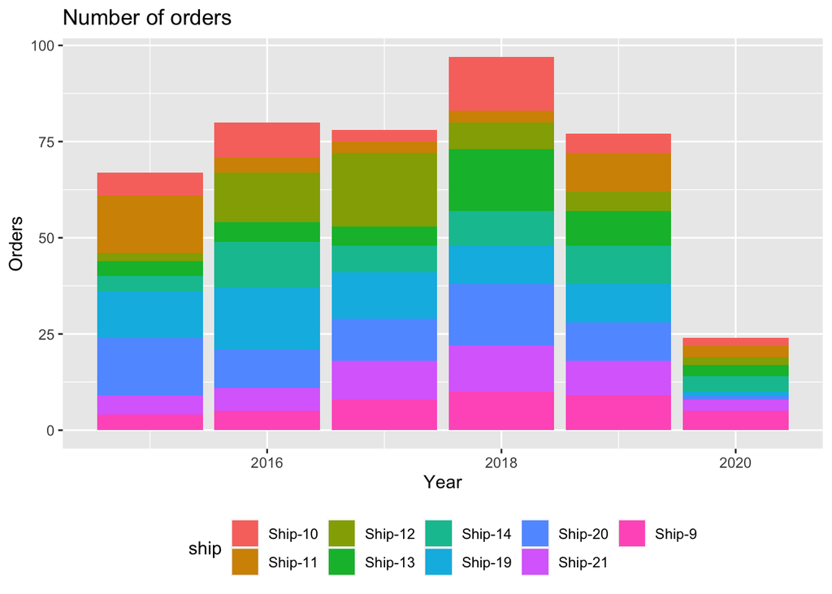

```r
dat %>%
   group_by(order_year, order_id) %>%
   summarise(ship = first(ship)) %>%
   ggplot(aes(x = order_year, fill = ship)) +
   geom_bar() +
   labs(title = "Number of orders",
    x = "Year",
    y = "Orders",
    col = "Ship") +
   theme(legend.position = "bottom")
```

```r
# or
# dat %>%
#    count(order_year, order_id, ship) %>%
#    ggplot(aes(x = order_year, fill = ship)) +
#    geom_bar()
```

Most orders are in 2018.

## Question 2

Create a visualization showing the total number of items ordered for each ship with the following features:

- The numbers are shown using columns.
- Reorder the columns so they increase along the x-axis.
- Informative figure title and axis titles are given.

Which ship uses most items?

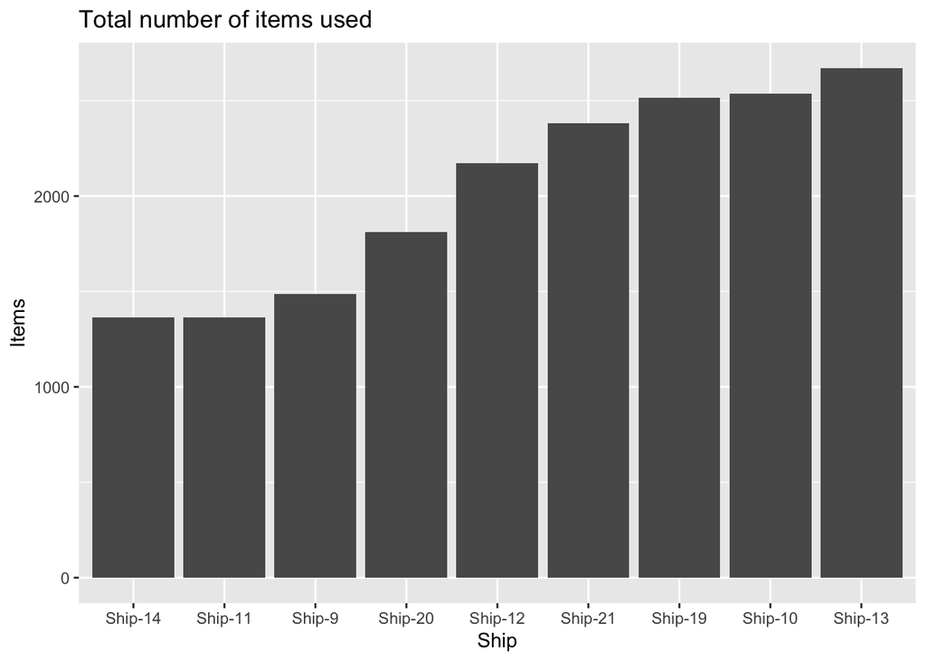

```r
res <- dat %>%
   group_by(ship) %>%
   summarize(n = sum(quantity)) %>%
   arrange(desc(n))
res %>%
   ggplot(aes(x = reorder(ship, n), y = n)) +
   geom_col() +
   labs(title = "Total number of items used",
    x = "Ship",
    y = "Items") +
   theme(legend.position = "bottom")
```

Most items are used for Ship-13.

## Question 3

For each ship, create a visualization showing the number of items used as a function of done date with the following features:

- The numbers are shown using columns with a fixed line width of 1 and a blue color.
- The plot is divided using `ship` (facet). Hint: You may use `scales = "free_y"`.
- Informative figure title and axis titles are given.

Which ship has most items used at a specific date?

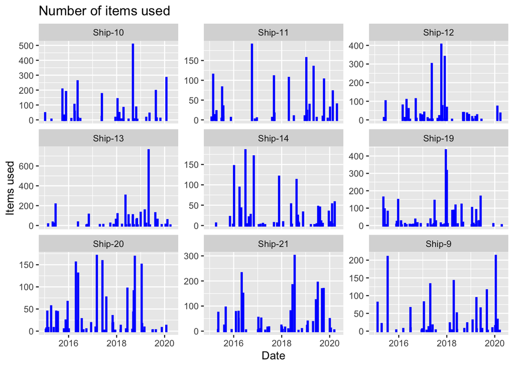

```r
res <- dat %>%
   group_by(ship, order_date) %>%
   summarize(n = sum(quantity))
res %>%
   ggplot(aes(x = order_date, y = n)) +
   geom_col(linewidth = 1, color = "blue") +
   facet_wrap(~ ship, scales = "free_y") +
   labs(title = "Number of items used",
    x = "Date",
    y = "Items used")
```

On a specific date must items are used for Ship-13.

## Question 4

Consider items with id:

```r
items <- c("601.003.004" ,"601.004.006", "601.026.128", "601.026.052")
```

For each row in the dataset, calculate an index variable as price divided with the maximum item id price. Hint: Group by item id and use `mutate` to add the column. Create a visualization showing the index as a function of order year with the following features:

- The numbers are shown using points.
- The plot is divided using item id (facet).
- A trend line is added.
- Informative figure title and axis titles are given.

Take a closer look at the item with most price fluctuations. Are the prices reasonable for a singe product?

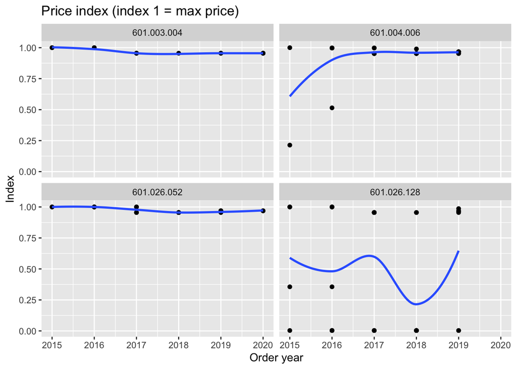

```r
res <- dat %>%
   filter(item_id %in% items) %>%
   group_by(item_id) %>%
   mutate(idx = price/max(price))
res %>%
   ggplot(aes(y = idx, x = order_year)) +
   geom_point() +
   geom_smooth(se = F) +
   facet_wrap(~ item_id) +
   labs(title = "Price index (index 1 = max price)",
    x = "Order year",
    y = "Index")
```

```r
dat %>%
   filter(item_id %in% "601.026.128")
```

```
## # A tibble: 34 × 13
##    ship    order…¹ item_id item_…² quant…³  price order_date delivery…⁴ deliv…⁵ received…⁶
##    <chr>     <dbl> <chr>   <chr>     <dbl>  <dbl> <date>     <date>     <chr>   <date>
##  1 Ship-19 3.76e11 601.02… Fuel v…      10 35083. 2015-05-12 2015-07-01 Delive… 2015-09-07
##  2 Ship-13 3.68e11 601.02… O-ring…      30   321. 2015-06-17 2015-06-23 Delive… 2015-07-02
##  3 Ship-20 3.76e11 601.02… Spindl…      14 98589. 2015-06-26 2015-08-19 Delive… 2015-10-10
##  4 Ship-21 3.77e11 601.02… Spindl…       4 98589. 2015-09-02 2015-09-20 Delive… 2015-11-12
##  5 Ship-14 3.68e11 601.02… O-ring…      12   321. 2016-01-07 2016-01-18 Delive… 2016-02-11
##  6 Ship-14 3.68e11 601.02… O-Ring       12   321. 2016-03-30 2016-04-06 Delive… 2016-05-26
##  7 Ship-21 3.77e11 601.02… Spindl…       7 98589. 2016-05-02 2016-07-07 Delive… 2016-08-08
##  8 Ship-20 3.76e11 601.02… Spindl…      12 98589. 2016-05-06 2016-05-10 Delive… 2016-06-16
##  9 Ship-10 3.57e11 601.02… O-Ring       20   321. 2016-05-17 2016-05-24 Delive… 2016-07-07
## 10 Ship-19 3.76e11 601.02… Fuel v…       7 35083. 2016-09-09 2016-10-07 Delive… 2016-11-06
## # … with 24 more rows, 3 more variables: supplier <chr>, delivery_cost <dbl>,
## #   order_year <dbl>, and abbreviated variable names ¹order_id, ²item_desc, ³quantity,
## #   ⁴delivery_date, ⁵delivery_place, ⁶received_date
```

If consider item 601.026.128 it can be seen that prices are very different. By considering item description it can be seen that the item is in fact not a single product, i.e we have a misclassification of item id!

## Question 5

Make a summary table in the following way:

- Add a column `val` with the value of an item in a row equaling the price times quantity.
- Group each item id and set the total value `total_value` to the sum of `val` and calculate the total quantity purchased.
- Arrange the total value in descending order.
- Add columns:
  - Relative total value equals `total_val/sum(total_val)`.
  - Relative item number equals `row_number()/n()`.
  - Cumulative relative total value (`cum_pct_val`). Hint: You can use the `cumsum` function here.
  - Class equals `class = case_when(cum_pct_val <= 0.8 ~ "A", cum_pct_val <= 0.95 ~ "B", TRUE ~ "C")` classifying items in A (high value items), B (middle), and C (low value items).

Create a visualization showing the cumulative relative total value as a function of relative item number with the following features:

- Data points are given in the plot.
- Different colors are used for each class.
- Different sizes are used for each quantity.
- A line is added with black color and fixed size 0.3.
- Informative figure title and axis titles are given.

How many items contribute to 80% of the total value?

```r
res1 <- dat %>%
   mutate(val = price * quantity) %>%
   group_by(item_id) %>%
   summarise(total_val = sum(val), item_desc = first(item_desc), quantity = sum(quantity)) %>%
   arrange(desc(total_val)) %>%
   mutate(pct_val = total_val/sum(total_val),
          pct_item = row_number()/n(),
          cum_pct_val = cumsum(pct_val),
          class = case_when(
            cum_pct_val <= 0.8 ~ "A",
            cum_pct_val <= 0.95  ~ "B",
            TRUE ~ "C"
         )) %>%
   # tail() %>%
   print()
```

```
## # A tibble: 550 × 8
##    item_id     total_val item_desc                   quant…¹ pct_val pct_i…² cum_p…³ class
##    <chr>           <dbl> <chr>                         <dbl>   <dbl>   <dbl>   <dbl> <chr>
##  1 601.003.004 20301030  Cylinder Liner IMO Number …      42  0.104  0.00182   0.104 A
##  2 601.026.139 16083341. Spindle Guide, Compl            169  0.0822 0.00364   0.186 A
##  3 601.004.008 15029349. Piston Crown IMO Number 18…      56  0.0768 0.00545   0.263 A
##  4 601.002.078 12592313. DuraSpindle                      62  0.0643 0.00727   0.327 A
##  5 601.026.128 11675816. Fuel valve head                 486  0.0596 0.00909   0.387 A
##  6 601.004.010  8046002. Piston Rod IMO Effective L…      11  0.0411 0.0109    0.428 A
##  7 601.026.049  7654587. Pump barrel with plunger, …      46  0.0391 0.0127    0.467 A
##  8 601.004.005  6631292. Piston ring, CPR-POP, H=9.…     154  0.0339 0.0145    0.501 A
##  9 601.004.006  5946707. Piston Ring No. 2 & 4           271  0.0304 0.0164    0.531 A
## 10 601.026.052  5436342. Suction valve                   135  0.0278 0.0182    0.559 A
## # … with 540 more rows, and abbreviated variable names ¹quantity, ²pct_item, ³cum_pct_val
```

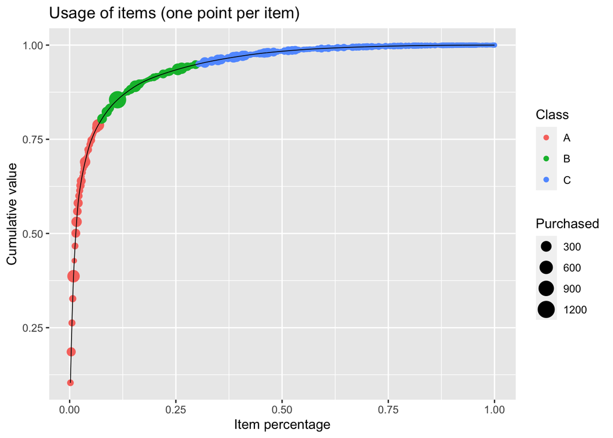

```r
res1 %>%
   ggplot(aes(x = pct_item, y = cum_pct_val, col = class, size = quantity)) +
   geom_point() +
   geom_line(col = "black", size = 0.3) +
   labs(title = "Usage of items (one point per item)",
    x = "Item percentage",
    y = "Cumulative value",
    col = "Class",
    size = "Purchased")
```

Items in the A class (80% of value) are approx. 7% of the total items.